# Data Mining

Mathieu VERON Alexandre JEANNE Pierre LARCHER

# Aperçu de la base de données

Cette base de données est composée de différentes données tirées de session utilisateur sur un site internet de vente en ligne. Chaque session correspond à un utilisateur différent sur une période d’un an. Elle contient 12330 observations correspondant à une session chacune pour 18 variables lesquelles sont décrites ci-dessous :

- **Nb_page_administrative** : Nombre de pages de catégories administrative visitées.
- **Duree_administrative** : Temps passé sur les pages de catégories administrative.
- **Nb_page_information** : Nombre de pages de catégories information visitées.
- **Duree_information** : Temps passé sur les pages de catégories information.
- **Nb_page_produit** : Nombre de pages de catégories produit visitées.
- **Duree_produit** : Temps passé sur les pages de catégories produit.
- **Pourcentage_pub_quit** : Pourcentage de consommateurs étant rentrés vient un lien publicitaire et ayant quitté directement.
- **Taux_sortie** : Pourcentage de fois que cette fois a été quittée par rapport aux autres.(Valeur par page?)
- **Page_av_achat** : Nombre de page visitée par un consommateur avant un achat.
- **Jour_special** : Jour particulier comme la Saint-Valentin par exemple.
- **mois** : Mois de l’année
- **Systeme_exploitation** : OS utilisé
- **Navigateur** : Navigateur utilisé
- **Pays** : Pays du consommateur
- **Type_trafic** : Type de traffic
- **Type_visiteur** : Nouveau ou ancien visiteur
- **Weekend** : Pendant le Week-End ou non
- **Achat** : S’il y a eu achat ou non

Nous avons choisi d’enlever la variable **Page_av_achat** pour des raisons de corrélation.

Voici un premier aperçu de la base de données.

|  | Nb_page_administrative | Duree_administrative | Nb_page_information | Duree_information | Nb_page_produit | Duree_produit | Pourcentage_pub_quit | Taux_sortie | Jour_special | Mois | Systeme_exploitation | Navigateur | Pays | Type_trafic | Type_visiteur | Weekend | Achat | Nb_page_total | Duree_total |
| --- | --- | --- | --- | --- | --- | --- | --- | --- | --- | --- | --- | --- | --- | --- | --- | --- | --- | --- | --- |
| 12325 | 0 | 0 | 1 | 0 | 16 | 503.000 | 0.0000000 | 0.0376471 | 0 | Nov | 2 | 2 | 1 | 1 | Anciens | Non | Non | 17 | 503.000 |
| 12326 | 3 | 145 | 0 | 0 | 53 | 1783.792 | 0.0071429 | 0.0290306 | 0 | Dec | 4 | 6 | 1 | 1 | Anciens | Oui | Non | 56 | 1928.792 |
| 12327 | 0 | 0 | 0 | 0 | 5 | 465.750 | 0.0000000 | 0.0213333 | 0 | Nov | 3 | 2 | 1 | 8 | Anciens | Oui | Non | 5 | 465.750 |
| 12328 | 0 | 0 | 0 | 0 | 6 | 184.250 | 0.0833333 | 0.0866667 | 0 | Nov | 3 | 2 | 1 | 13 | Anciens | Oui | Non | 6 | 184.250 |
| 12329 | 4 | 75 | 0 | 0 | 15 | 346.000 | 0.0000000 | 0.0210526 | 0 | Nov | 2 | 2 | 3 | 11 | Anciens | Non | Non | 19 | 421.000 |
| 12330 | 0 | 0 | 0 | 0 | 3 | 21.250 | 0.0000000 | 0.0666667 | 0 | Nov | 3 | 2 | 1 | 2 | Nouveaux | Oui | Non | 3 | 21.250 |

On remarque que nous n’avons pas de valeurs manquantes dans cette base de données. En revanche nous n’avons pas de renseignements sur les variables **Pays, Systeme_explotation, Navigateur** et la signification des valeurs qu’elles prennent.

# Analyse descriptive

## Variables quantitatives

|  | Nb_page_administrative | Duree_administrative | Nb_page_information | Duree_information | Nb_page_produit | Duree_produit | Pourcentage_pub_quit | Taux_sortie | Jour_special | Mois | Navigateur | Pays | Type_trafic | Type_visiteur | Duree_total |
| --- | --- | --- | --- | --- | --- | --- | --- | --- | --- | --- | --- | --- | --- | --- | --- |
|  | Min. : 0.000 | Min. : 0.00 | Min. : 0.0000 | Min. : 0.00 | Min. : 0.00 | Min. : 0.0 | Min. :0.000000 | Min. :0.00000 | Min. :0.00000 | May :3364 | Min. : 1.000 | Min. :1.000 | Min. : 1.00 | Nouveaux: 1694 | Min. : 0 |
|  | 1st Qu.: 0.000 | 1st Qu.: 0.00 | 1st Qu.: 0.0000 | 1st Qu.: 0.00 | 1st Qu.: 7.00 | 1st Qu.: 184.1 | 1st Qu.:0.000000 | 1st Qu.:0.01429 | 1st Qu.:0.00000 | Nov :2998 | 1st Qu.: 2.000 | 1st Qu.:1.000 | 1st Qu.: 2.00 | Autres : 85 | 1st Qu.: 222 |
|  | Median : 1.000 | Median : 7.50 | Median : 0.0000 | Median : 0.00 | Median : 18.00 | Median : 598.9 | Median :0.003112 | Median :0.02516 | Median :0.00000 | Mar :1907 | Median : 2.000 | Median :3.000 | Median : 2.00 | Anciens :10551 | Median : 680 |
|  | Mean : 2.315 | Mean : 80.82 | Mean : 0.5036 | Mean : 34.47 | Mean : 31.73 | Mean : 1194.8 | Mean :0.022191 | Mean :0.04307 | Mean :0.06143 | Dec :1727 | Mean : 2.357 | Mean :3.147 | Mean : 4.07 | NA | Mean : 1310 |
|  | 3rd Qu.: 4.000 | 3rd Qu.: 93.26 | 3rd Qu.: 0.0000 | 3rd Qu.: 0.00 | 3rd Qu.: 38.00 | 3rd Qu.: 1464.2 | 3rd Qu.:0.016813 | 3rd Qu.:0.05000 | 3rd Qu.:0.00000 | Oct : 549 | 3rd Qu.: 2.000 | 3rd Qu.:4.000 | 3rd Qu.: 4.00 | NA | 3rd Qu.: 1627 |
|  | Max. :27.000 | Max. :3398.75 | Max. :24.0000 | Max. :2549.38 | Max. :705.00 | Max. :63973.5 | Max. :0.200000 | Max. :0.20000 | Max. :1.00000 | Sep : 448 | Max. :13.000 | Max. :9.000 | Max. :20.00 | NA | Max. :69922 |
|  | NA | NA | NA | NA | NA | NA | NA | NA | NA | (Other):1337 | NA | NA | NA | NA | NA |

Aucune précision concernant l’unité des données n’a été apporté. En vu du summary, nous considérerons le temps exprimé en seconde comme unité temporelle, converti en numéraire. Cependant le choix d’unité temporelle n’a aucune incidence en terme de prédiction et création de modèle. Son importance est seulement notable en interprétation.

## Variable qualitative

```
##  Nb_page_total    Achat       Weekend    Systeme_exploitation
##  Min.   :  0.00   Non:10422   Non:9462   Min.   :1.000
##  1st Qu.:  8.00   Oui: 1908   Oui:2868   1st Qu.:2.000
##  Median : 20.00                          Median :2.000
##  Mean   : 34.55                          Mean   :2.124
##  3rd Qu.: 42.00                          3rd Qu.:3.000
##  Max.   :746.00                          Max.   :8.000
```

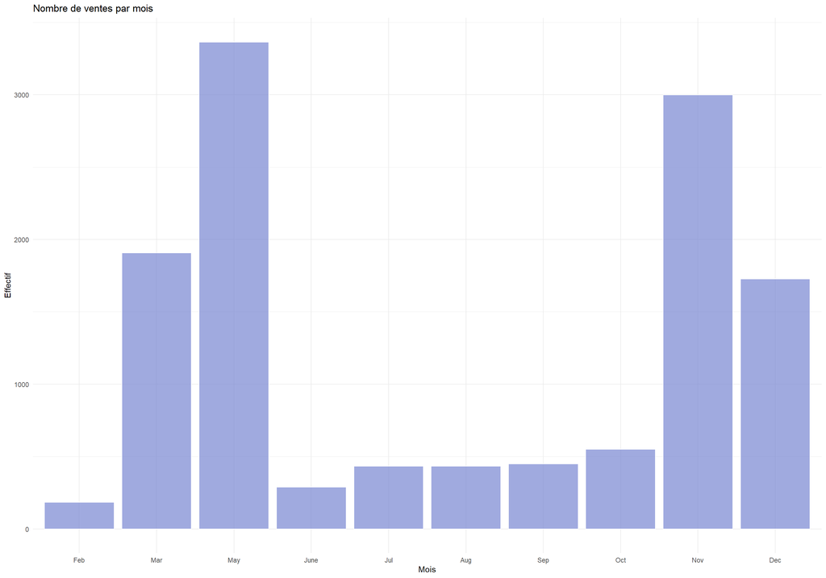

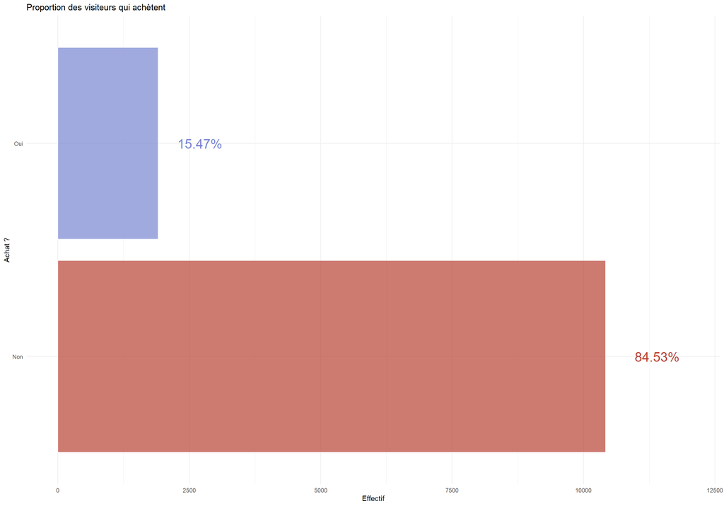

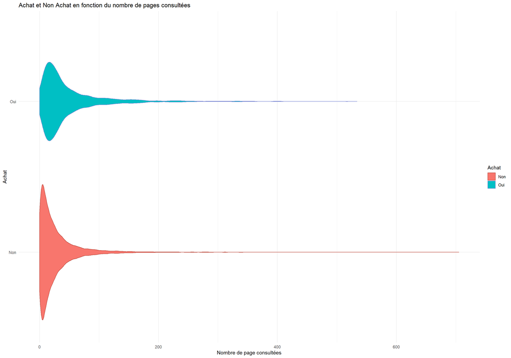

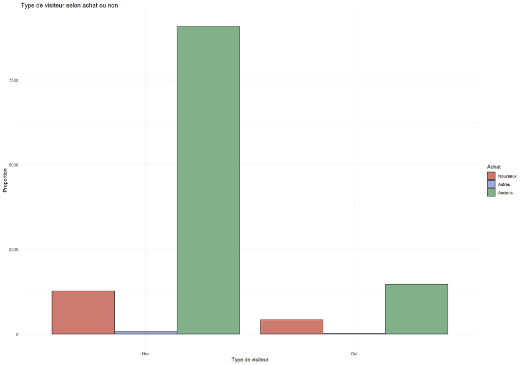

# KNN

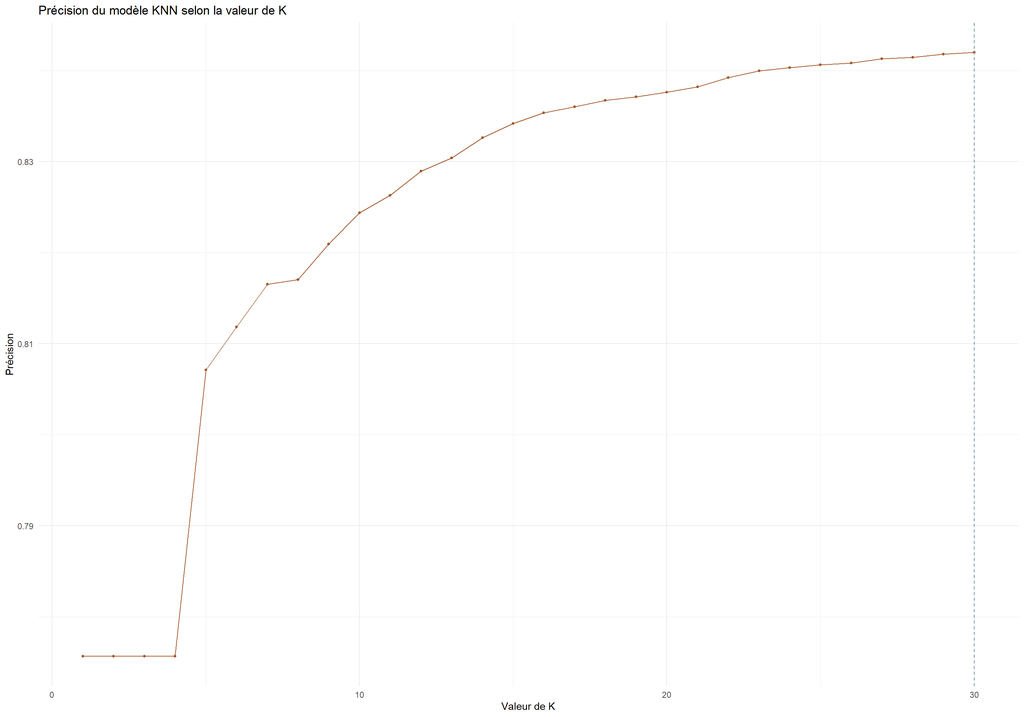

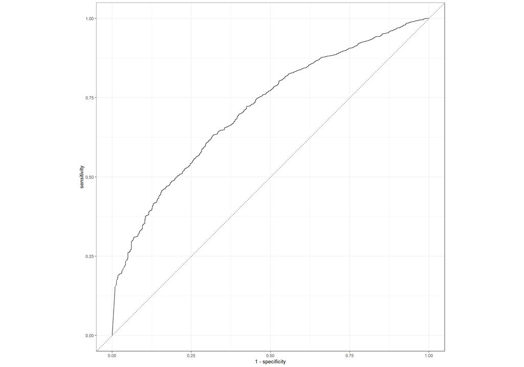

```
##           Truth
## Prediction  Non  Oui
##        Non 3436  602
##        Oui   38   34
```

# LDA

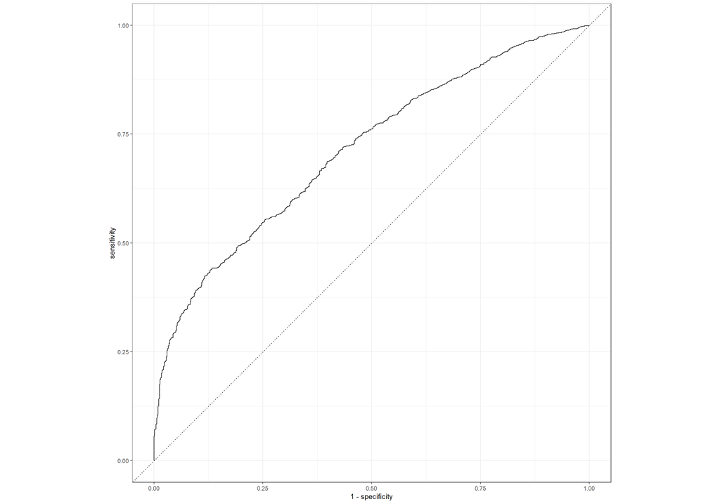

```
##           Truth
## Prediction  Non  Oui
##        Non 3445  611
##        Oui   29   25
```

```
## # A tibble: 1 x 3
##   .metric .estimator .estimate
##   <chr>   <chr>          <dbl>
## 1 roc_auc binary         0.713
```

# QDA

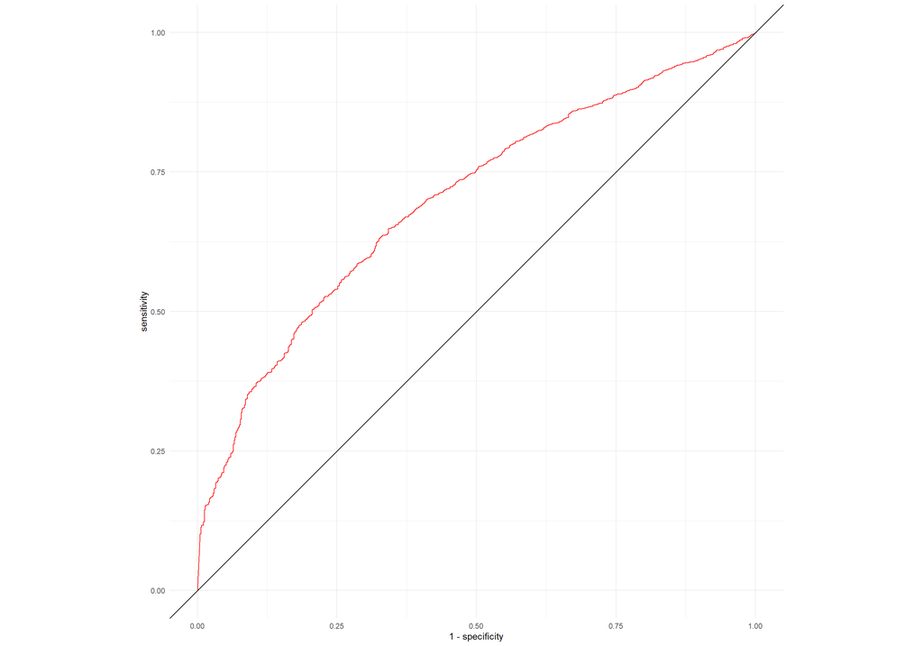

```
## # A tibble: 1 x 3
##   .metric .estimator .estimate
##   <chr>   <chr>          <dbl>
## 1 roc_auc binary         0.699
```

```
##           Truth
## Prediction  Non  Oui
##        Non 2060  191
##        Oui 1414  445
```

# **Comparaison LDA QDA KNN**

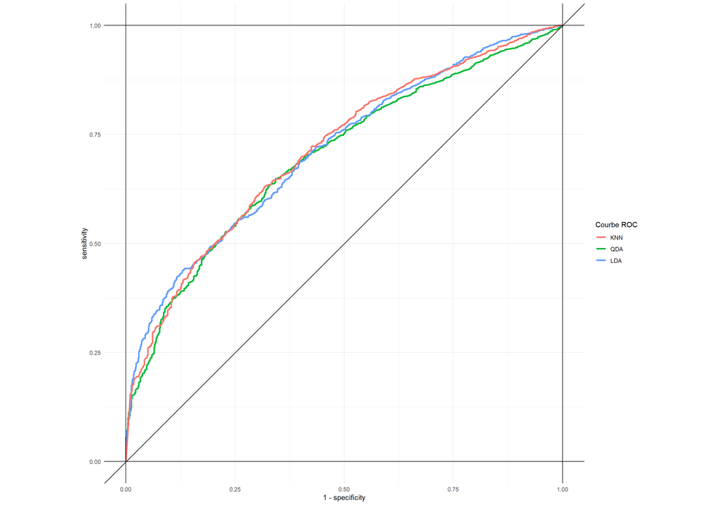

# Arbres

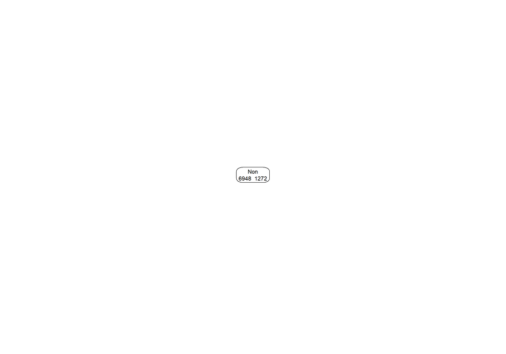

```
##           Truth
## Prediction  Non  Oui
##        Non 3474  636
##        Oui    0    0
```

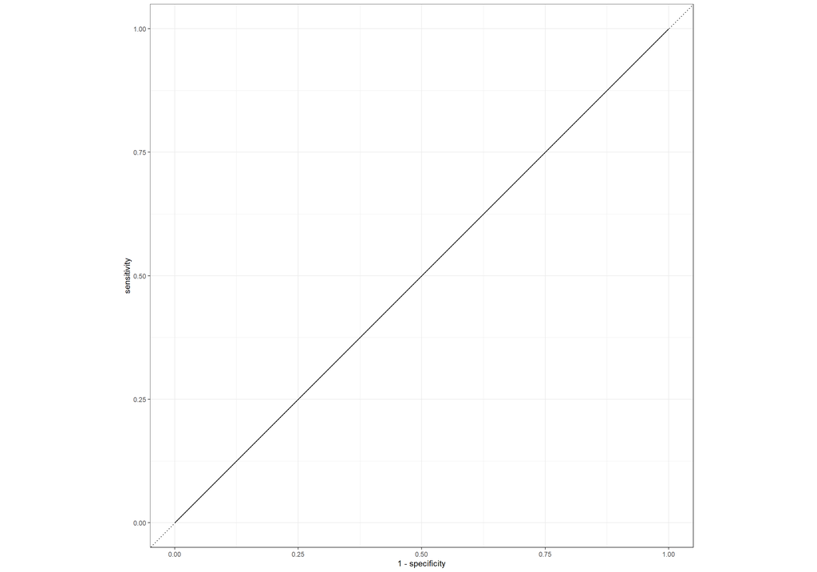